# Experiments&Snippets

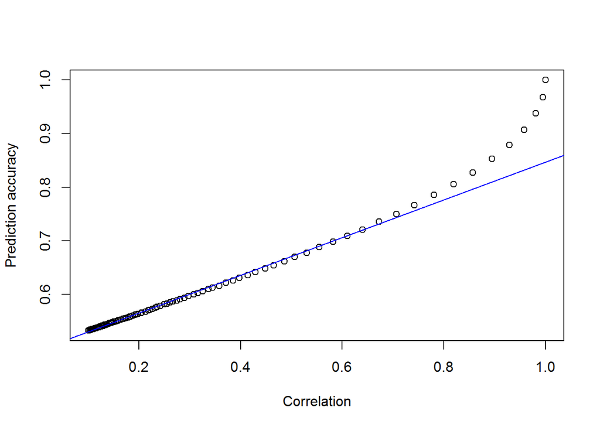

```r
# попробуем построить зависимость
# доля правильных предсказаний от стандартного отклонения ошибки

dep_list = lapply(seq(0,10,0.1),function(eps_sd) {rowMeans(replicate(1000,{
    x = rnorm(N)
    y = x + rnorm(N,mean = 0, sd = eps_sd)
    c(eps_sd, cor(x,y),
    mean(sign(diff(y))==sign(diff(x))))

}))})

dep_mat=as.data.frame(do.call(rbind,dep_list))
colnames(dep_mat) = c("Error SD","Correlation","Prediction accuracy")
plot(dep_mat[,2:3]) # тут непонятная зависимость, но на начальных этапах похожа на линейную
mod1 = lm(`Prediction accuracy` ~ Correlation, data = dep_mat,subset=Correlation<0.8)
abline(mod1,col="blue")
```

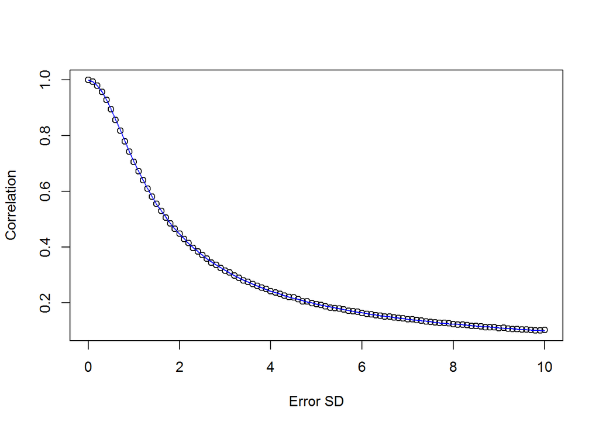

```r
plot(dep_mat[,1:2]) # зависимость должна быть как sqrt(1/(1+eps_sd^2)), так как квадрат корреляции - это доля объясненной вариации
eps_sd = seq(0,10,0.1)
lines(eps_sd,sqrt(1/(1+eps_sd^2)),col="blue") # тютелька в тютельку:)
```

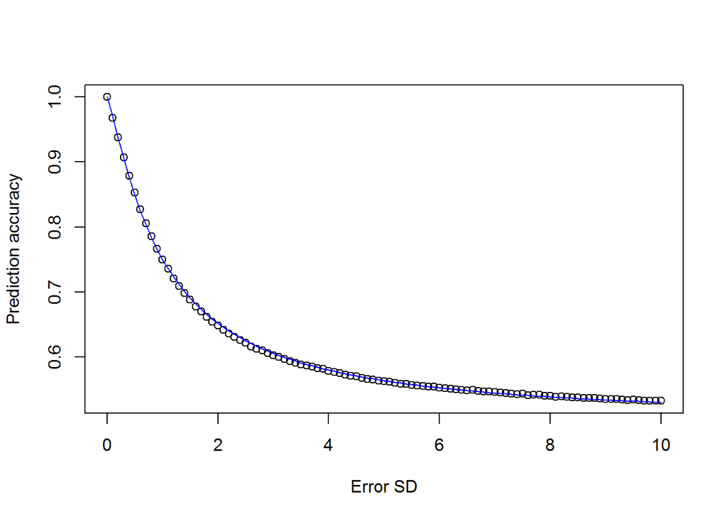

```r
plot(dep_mat[,c(1,3)]) # в виде гипотезы 0.5+0.5/(1+eps_sd)
with(dep_mat,lines(`Error SD`,0.5+0.5/(1+(`Error SD`)^1.2),col="blue")) # еле-еле похоже... подогнал кривулькой с показателем степени 1.2 - очень странно
```

```r
# нелинейную модель так и не удалось подогнать...
# colnames(dep_mat)[3] = "pred"
# nls_mat = data.frame(pred = dep_mat[,"Prediction accuracy"] + rnorm(nrow(dep_mat), sd = 0.01),Correlation = dep_mat[,"Correlation"])
# mod2 = nls(pred ~ base + a/(d+Correlation^alfa), data = nls_mat,start=c(base=0.5,a=0.5,d=1,alfa=1))
# а если линейную
mod3 = lm(`Prediction accuracy` ~ I(0.5+0.5/(1+(`Error SD`)^1.2)), data = dep_mat)
summary(mod3) # нереально хороший р-квадрат
```

```
##
## Call:
## lm(formula = `Prediction accuracy` ~ I(0.5 + 0.5/(1 + (`Error SD`)^1.2)),
##     data = dep_mat)
##
## Residuals:
##        Min         1Q     Median         3Q        Max
## -0.0043870 -0.0014957  0.0001252  0.0017337  0.0051416
##
## Coefficients:
##                                      Estimate Std. Error t value Pr(>|t|)
## (Intercept)                         0.0007381  0.0013044   0.566    0.573
## I(0.5 + 0.5/(1 + (`Error SD`)^1.2)) 0.9982671  0.0021181 471.294   <2e-16
##
## (Intercept)
## I(0.5 + 0.5/(1 + (`Error SD`)^1.2)) ***
## ---
## Signif. codes:  0 '***' 0.001 '**' 0.01 '*' 0.05 '.' 0.1 ' ' 1
##
## Residual standard error: 0.002207 on 99 degrees of freedom
## Multiple R-squared:  0.9996, Adjusted R-squared:  0.9995
## F-statistic: 2.221e+05 on 1 and 99 DF,  p-value: < 2.2e-16
```

А мораль всего этого такая - что простой ответ на этот простой вопрос я не нашел.

### 2015-02-11 DiagrammeR

Кириллицу мы не поддерживаем…:( Да и с масштабированием проблемы. И вообще странно работает.

```r
library(DiagrammeR)

DiagrammeR("
           graph TB;
           A{Life} -->B(Family);
           A --> C[Work];
           ")
```

[interactive chart not shown]

### 2015-03-13 Заключенные и 100 ящиков

По условию задачи в тюрьме находится 100 заключенных, каждый из которых имеет личный номер от 1 до 100. Тюремщик решает дать заключенным шанс на освобождение и предлагает пройти придуманное им испытание. Если все заключенные справятся, то они свободны, если хотя бы один провалится — все умрут.

Тюремщик идет в секретную комнату и подготавливает 100 коробок с крышками. На каждую коробку он наносит числа с нумерацией от 1 до 100. Затем он приносит 100 бумажных табличек, по числу заключенных, и нумерует эти таблички от 1 до 100. После этого он перемешивает 100 табличек и помещает в каждую коробку по одной табличке, закрывая крышку. Заключенные не видят, как тюремщик выполняет все эти действия. Соревнование начинается, тюремщик отводит каждого заключенного по одному в комнату с коробками и говорит заключенным, что они должны найти коробку, в которой будет находиться табличка с номером заключенного. Заключенные пытаются найти табличку со своим номером, открывая коробки. Каждому разрешается открыть до 50-ти коробок; если каждый из заключенных найдет свой номер, то заключенных отпустят, если хотя бы один из них не найдет свой номер за 50 попыток, то все заключенные умрут. Для того, чтобы заключенные были освобождены, ВСЕ заключенные должны пройти испытание успешно.

Так какой же шанс, что заключенных помилуют?

- После открытия коробки заключенным и проверки им таблички она помещается обратно в коробку и крышка снова закрывается;
- Местами таблички менять нельзя;
- Заключенные не могут оставлять друг другу подсказки или как-то взаимодействовать друг с другом после начала испытания;
- Заключенным разрешается обсудить стратегию до начала испытания.

```r
# zk_count - количеcтво заключенных
# max_trial - количество попыток у одного заключенного

single_experiment = function(zk_count, max_trial){

    zk_num = seq_len(zk_count) # последовательно нумеруем заключенных
    boxes = sample(zk_num) # помещаем и перемешиваем номера заключенных в коробках

    zk_success = 0 # количество заключенных, которые нашли свои номера за max_trial попыток

    for (zk in zk_num){ # перебираем заключенных
        box = zk # номер вскрываемого ящика
        trial = 1 # номер попытки
        # в этом цикле каждый заключенный вскрывает ящики
        while (trial <=max_trial){
            if (boxes[box] == zk){
                # успех, он нашел свой номер
                zk_success = zk_success + 1
                break # дальше не пробуем
            } else {
                    box = boxes[box] # берем номер ящика, куда смотреть даальше
            }
            trial = trial + 1
        }
    }
    zk_success # возвращаем количество заключенных, которые нашли свои номера
}

set.seed(123) # чтобы была воспроизводимость
library(compiler)
cmp_se = cmpfun(single_experiment)

system.time({
    results =replicate(100000,cmp_se(100,50))
})
```

```
##    user  system elapsed
##   46.59    0.02   46.67
```

```r
mean(results==100) # доля успешных экспериментов
```

```
## [1] 0.3125
```

```r
system.time({
    giper_results =replicate(100, mean(replicate(500,cmp_se(100,50))==100))
    })
```

```
##    user  system elapsed
##   25.64    0.00   25.69
```

```r
summary(giper_results)
```

```
##    Min. 1st Qu.  Median    Mean 3rd Qu.    Max.
##  0.2600  0.2960  0.3090  0.3098  0.3220  0.3660
```

```r
quantile(giper_results, c(0.025,0.975))
```

```
##    2.5%   97.5%
## 0.27200 0.34905
```

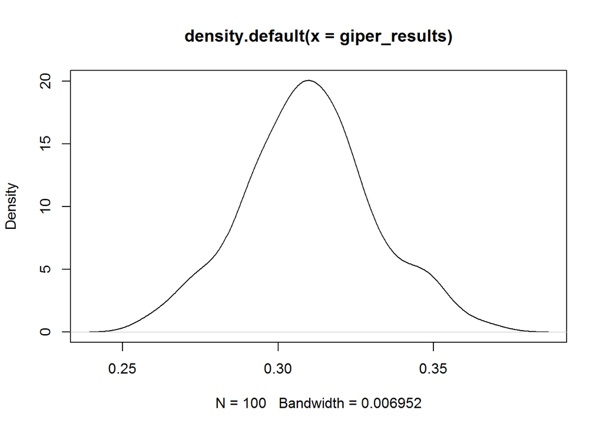

```r
plot(density(giper_results))
```

```r
# для 100 раз по 10000
#      2.5%     97.5%
# 0.3031800 0.3215675
```